# 2025-sample-sequencing-run

diana baetscher

2026-04-17

MiSeq run on 2026-04-13 using a 2x300 cycle kit.

```bash
# preliminaries to get cutadapt going
(base) AKCJM140-DB23:cutadapt_mismatches diana.baetscher$ conda activate cutadaptenv

DATA=/Users/diana.baetscher/git-repos/HAPO/data/20260413_HAPOeDNA/rawdata

# below, the first set of () creates an array, containing n elements of the desired trimmed and unique names
NAMELIST=$(ls ${DATA} | sed 's/e*_L001.*//' | uniq)
echo "${NAMELIST}"
```

```bash
# cutadapt remove primers
# unlike in the previous microkit runs, here we have paired-end data that should include both the fwd and reverse primers
# using the -b (anywhere adapter syntax fixed the issue)
for i in ${NAMELIST}; do
    cutadapt --discard-untrimmed -b TACTCCTTGAAAAAGCCCATTGTA -B ATGGTCCTGAAGTAAGAACCAGATG -o trimmed/${i}_R1.fastq.gz -p trimmed/${i}_R2.fastq.gz "$DATA/${i}_L001_R1_001.fastq.gz" "$DATA/${i}_L001_R2_001.fastq.gz" >> cutadapt_out.txt
    done


# then unzip the reads in the /trimmed directory
pigz -d *gz
```

Notes about the “anywhere” adapter from Cutadapt docs: For this type of adapter, the sequence is specified with -b ADAPTER (or use the longer spelling –anywhere ADAPTER). The adapter may appear in the beginning (even degraded), within the read, or at the end of the read (even partially). The decision which part of the read to remove is made as follows: If there is at least one base before the found adapter, then the adapter is considered to be a 3’ adapter and the adapter itself and everything following it is removed. Otherwise, the adapter is considered to be a 5’ adapter and it is removed from the read, but the sequence after it remains.

Are there empty files? If so, I should move them before they cause trouble:

```bash
find /Users/diana.baetscher/git-repos/HAPO/data/20260413_HAPOeDNA/trimmed -type f -empty -exec mv {} /Users/diana.baetscher/git-repos/HAPO/data/20260413_HAPOeDNA/trimmed_empty/ \;
```

None, presently.

## Dada2 and ASV analysis

Launching into the R-portion of the analysis in dada2

```r
library(dada2)
library(tidyverse)
# file location
path <- "../data/20260413_HAPOeDNA/trimmed"

list.files(path)
```

```
##   [1] "e05548-1_S1_R1.fastq"   "e05548-1_S1_R2.fastq"   "e05548-2_S63_R1.fastq"
##   [4] "e05548-2_S63_R2.fastq"  "e05548-3_S125_R1.fastq" "e05548-3_S125_R2.fastq"
##   [7] "e05549-1_S2_R1.fastq"   "e05549-1_S2_R2.fastq"   "e05549-2_S64_R1.fastq"
##  [10] "e05549-2_S64_R2.fastq"  "e05549-3_S126_R1.fastq" "e05549-3_S126_R2.fastq"
##  [13] "e05550-1_S3_R1.fastq"   "e05550-1_S3_R2.fastq"   "e05550-2_S65_R1.fastq"
##  [16] "e05550-2_S65_R2.fastq"  "e05550-3_S127_R1.fastq" "e05550-3_S127_R2.fastq"
##  [19] "e05551-1_S4_R1.fastq"   "e05551-1_S4_R2.fastq"   "e05551-2_S66_R1.fastq"
##  [22] "e05551-2_S66_R2.fastq"  "e05551-3_S128_R1.fastq" "e05551-3_S128_R2.fastq"
##  [25] "e05552-1_S5_R1.fastq"   "e05552-1_S5_R2.fastq"   "e05552-2_S67_R1.fastq"
##  [28] "e05552-2_S67_R2.fastq"  "e05552-3_S129_R1.fastq" "e05552-3_S129_R2.fastq"
##  [31] "e05553-1_S6_R1.fastq"   "e05553-1_S6_R2.fastq"   "e05553-2_S68_R1.fastq"
##  [34] "e05553-2_S68_R2.fastq"  "e05553-3_S130_R1.fastq" "e05553-3_S130_R2.fastq"
##  [37] "e05554-1_S7_R1.fastq"   "e05554-1_S7_R2.fastq"   "e05554-2_S69_R1.fastq"
##  [40] "e05554-2_S69_R2.fastq"  "e05554-3_S131_R1.fastq" "e05554-3_S131_R2.fastq"
##  [43] "e05555-1_S8_R1.fastq"   "e05555-1_S8_R2.fastq"   "e05555-2_S70_R1.fastq"
```

[output cut: 110 more lines]

```r
# paired-end data
fnFs <- sort(list.files(path, pattern = "_R1.fastq", full.names = TRUE))
fnRs <- sort(list.files(path, pattern = "_R2.fastq", full.names = TRUE))
# Extract sample names, assuming filenames have format: SAMPLENAME_XXX.fastq
sample.names <- sapply(strsplit(basename(fnFs), "_"), `[`, 1)
```

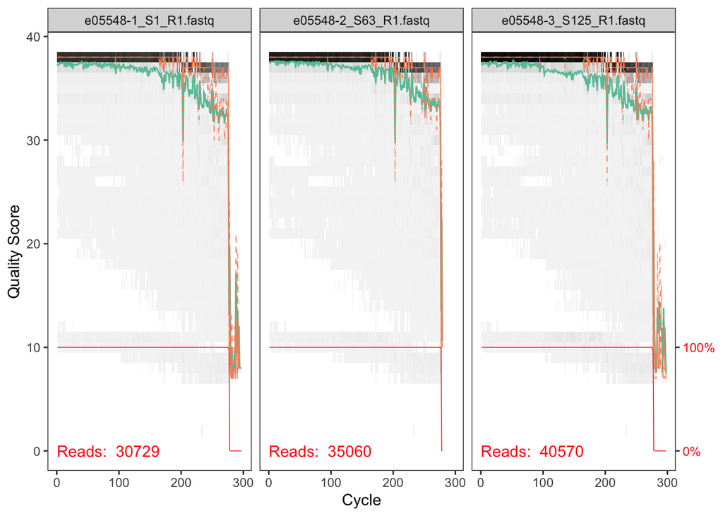

```r
plotQualityProfile(fnFs[1:3])
```

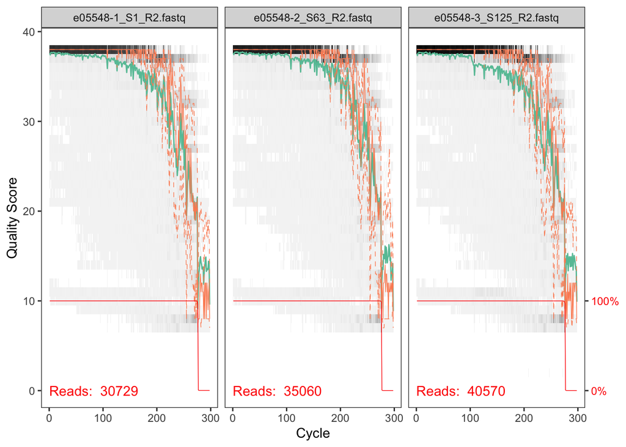

```r
plotQualityProfile(fnRs[1:3])
```

These are classic 600-cycle kit patterns, where the forward read is much higher quality at the later cycles than the reverse read. Consequently, let’s trim to 250 in the FWD and 200 in the REV. That should still give us >20 bp of overlap.

```r
# Place filtered files in filtered/ subdirectory
filtFs <- file.path(path, "filtered", paste0(sample.names, "_F_filt.fastq.gz"))
filtRs <- file.path(path, "filtered", paste0(sample.names, "_R_filt.fastq.gz"))
names(filtFs) <- sample.names
names(filtRs) <- sample.names
```

Change truncLen to see how that affects downstream processing.

```r
out <- filterAndTrim(fnFs, filtFs, fnRs, filtRs, truncLen=c(250,200),
              maxN=0, maxEE=c(2,4), truncQ=2, rm.phix=TRUE,
              compress=TRUE, multithread=TRUE)
head(out)
```

```
##                        reads.in reads.out
## e05548-1_S1_R1.fastq      30729     27420
## e05548-2_S63_R1.fastq     35060     32368
## e05548-3_S125_R1.fastq    40570     36166
## e05549-1_S2_R1.fastq      33953     29630
## e05549-2_S64_R1.fastq     32890     30582
## e05549-3_S126_R1.fastq    35917     29932
```

### Error rates

```r
fwd_list <- as.list(filtFs)
rev_list <- as.list(filtRs)

new_list <- fwd_list[1:10] # smaller amount of data for learning the error rates.
new_list2 <- rev_list[1:10]


# fwd error rates
errF <- learnErrors(new_list, multithread=TRUE)
```

```
## 47229000 total bases in 188916 reads from 10 samples will be used for learning the error rates.
```

```r
# reverse error rates
errR <- learnErrors(new_list2, multithread=TRUE)
```

```
## 37783200 total bases in 188916 reads from 10 samples will be used for learning the error rates.
```

```r
0
```

```
## [1] 0
```

```r
# plot the erors
p1 <- plotErrors(errF, nominalQ=TRUE)
p2 <- plotErrors(errR, nominalQ=TRUE)
```

### Sample inference

```r
# forwards
dadaFs <- dada(filtFs, err=errF, multithread=TRUE)
```

```
## Sample 1 - 27420 reads in 5532 unique sequences.
## Sample 2 - 32368 reads in 5998 unique sequences.
## Sample 3 - 36166 reads in 6770 unique sequences.
## Sample 4 - 29630 reads in 5870 unique sequences.
## Sample 5 - 30582 reads in 5861 unique sequences.
## Sample 6 - 29932 reads in 7128 unique sequences.
## Sample 7 - 57 reads in 22 unique sequences.
## Sample 8 - 65 reads in 28 unique sequences.
## Sample 9 - 60 reads in 28 unique sequences.
## Sample 10 - 2636 reads in 710 unique sequences.
## Sample 11 - 392 reads in 158 unique sequences.
## Sample 12 - 1981 reads in 660 unique sequences.
## Sample 13 - 1574 reads in 488 unique sequences.
## Sample 14 - 773 reads in 262 unique sequences.
## Sample 15 - 1641 reads in 519 unique sequences.
## Sample 16 - 4 reads in 3 unique sequences.
## Sample 17 - 2 reads in 2 unique sequences.
## Sample 18 - 6 reads in 6 unique sequences.
## Sample 19 - 23094 reads in 4195 unique sequences.
## Sample 20 - 15521 reads in 3019 unique sequences.
## Sample 21 - 23422 reads in 4448 unique sequences.
## Sample 22 - 24973 reads in 4422 unique sequences.
## Sample 23 - 12076 reads in 2445 unique sequences.
## Sample 24 - 25630 reads in 4824 unique sequences.
## Sample 25 - 49063 reads in 7840 unique sequences.
## Sample 26 - 26673 reads in 4629 unique sequences.
## Sample 27 - 41726 reads in 7255 unique sequences.
## Sample 28 - 17882 reads in 3197 unique sequences.
## Sample 29 - 26524 reads in 5084 unique sequences.
## Sample 30 - 25684 reads in 4897 unique sequences.
## Sample 31 - 462 reads in 334 unique sequences.
## Sample 32 - 420 reads in 308 unique sequences.
## Sample 33 - 305 reads in 242 unique sequences.
## Sample 34 - 182 reads in 102 unique sequences.
## Sample 35 - 191 reads in 124 unique sequences.
## Sample 36 - 362 reads in 269 unique sequences.
## Sample 37 - 50 reads in 14 unique sequences.
## Sample 38 - 48 reads in 18 unique sequences.
## Sample 39 - 55 reads in 24 unique sequences.
## Sample 40 - 3035 reads in 838 unique sequences.
```

[output cut: 131 more lines]

```
## Sample 172 - 62 reads in 28 unique sequences.
## Sample 173 - 35 reads in 19 unique sequences.
## Sample 174 - 33 reads in 16 unique sequences.
## Sample 175 - 10 reads in 10 unique sequences.
## Sample 176 - 21 reads in 13 unique sequences.
## Sample 177 - 10 reads in 7 unique sequences.
## Sample 178 - 219 reads in 77 unique sequences.
## Sample 179 - 92 reads in 40 unique sequences.
## Sample 180 - 112 reads in 38 unique sequences.
## Sample 181 - 3 reads in 3 unique sequences.
## Sample 182 - 5 reads in 3 unique sequences.
## Sample 183 - 3 reads in 3 unique sequences.
## Sample 184 - 98534 reads in 15789 unique sequences.
## Sample 185 - 97715 reads in 15448 unique sequences.
## Sample 186 - 83889 reads in 13930 unique sequences.
```

```r
# reverses
dadaRs <- dada(filtRs, err=errR, multithread=TRUE)
```

```
## Sample 1 - 27420 reads in 3548 unique sequences.
## Sample 2 - 32368 reads in 3752 unique sequences.
## Sample 3 - 36166 reads in 4140 unique sequences.
## Sample 4 - 29630 reads in 3844 unique sequences.
## Sample 5 - 30582 reads in 3732 unique sequences.
## Sample 6 - 29932 reads in 4422 unique sequences.
## Sample 7 - 57 reads in 29 unique sequences.
## Sample 8 - 65 reads in 30 unique sequences.
## Sample 9 - 60 reads in 23 unique sequences.
## Sample 10 - 2636 reads in 524 unique sequences.
## Sample 11 - 392 reads in 133 unique sequences.
## Sample 12 - 1981 reads in 422 unique sequences.
## Sample 13 - 1574 reads in 326 unique sequences.
## Sample 14 - 773 reads in 195 unique sequences.
## Sample 15 - 1641 reads in 377 unique sequences.
## Sample 16 - 4 reads in 3 unique sequences.
## Sample 17 - 2 reads in 2 unique sequences.
## Sample 18 - 6 reads in 6 unique sequences.
## Sample 19 - 23094 reads in 2739 unique sequences.
## Sample 20 - 15521 reads in 2029 unique sequences.
## Sample 21 - 23422 reads in 3071 unique sequences.
## Sample 22 - 24973 reads in 2879 unique sequences.
## Sample 23 - 12076 reads in 1618 unique sequences.
## Sample 24 - 25630 reads in 3183 unique sequences.
## Sample 25 - 49063 reads in 5212 unique sequences.
## Sample 26 - 26673 reads in 2882 unique sequences.
## Sample 27 - 41726 reads in 4689 unique sequences.
## Sample 28 - 17882 reads in 2105 unique sequences.
## Sample 29 - 26524 reads in 3151 unique sequences.
## Sample 30 - 25684 reads in 3024 unique sequences.
## Sample 31 - 462 reads in 310 unique sequences.
## Sample 32 - 420 reads in 305 unique sequences.
## Sample 33 - 305 reads in 221 unique sequences.
## Sample 34 - 182 reads in 96 unique sequences.
## Sample 35 - 191 reads in 99 unique sequences.
## Sample 36 - 362 reads in 266 unique sequences.
## Sample 37 - 50 reads in 17 unique sequences.
## Sample 38 - 48 reads in 23 unique sequences.
## Sample 39 - 55 reads in 25 unique sequences.
## Sample 40 - 3035 reads in 555 unique sequences.
```

[output cut: 131 more lines]

```
## Sample 172 - 62 reads in 31 unique sequences.
## Sample 173 - 35 reads in 19 unique sequences.
## Sample 174 - 33 reads in 15 unique sequences.
## Sample 175 - 10 reads in 6 unique sequences.
## Sample 176 - 21 reads in 8 unique sequences.
## Sample 177 - 10 reads in 6 unique sequences.
## Sample 178 - 219 reads in 82 unique sequences.
## Sample 179 - 92 reads in 34 unique sequences.
## Sample 180 - 112 reads in 42 unique sequences.
## Sample 181 - 3 reads in 2 unique sequences.
## Sample 182 - 5 reads in 4 unique sequences.
## Sample 183 - 3 reads in 2 unique sequences.
## Sample 184 - 98534 reads in 8387 unique sequences.
## Sample 185 - 97715 reads in 7963 unique sequences.
## Sample 186 - 83889 reads in 7440 unique sequences.
```

Merge paired end reads

```r
mergers <- mergePairs(dadaFs, filtFs, dadaRs, filtRs, verbose=TRUE)
```

```
## 27362 paired-reads (in 6 unique pairings) successfully merged out of 27362 (in 6 pairings) input.
```

```
## 32228 paired-reads (in 9 unique pairings) successfully merged out of 32308 (in 15 pairings) input.
```

```
## 36037 paired-reads (in 9 unique pairings) successfully merged out of 36070 (in 11 pairings) input.
```

```
## 29332 paired-reads (in 7 unique pairings) successfully merged out of 29583 (in 13 pairings) input.
```

```
## 30487 paired-reads (in 8 unique pairings) successfully merged out of 30539 (in 14 pairings) input.
```

```
## 28229 paired-reads (in 20 unique pairings) successfully merged out of 29876 (in 31 pairings) input.
```

```
## 56 paired-reads (in 1 unique pairings) successfully merged out of 56 (in 1 pairings) input.
```

```
## 64 paired-reads (in 1 unique pairings) successfully merged out of 64 (in 1 pairings) input.
```

```
## 54 paired-reads (in 1 unique pairings) successfully merged out of 54 (in 1 pairings) input.
```

```
## 2628 paired-reads (in 1 unique pairings) successfully merged out of 2628 (in 1 pairings) input.
```

```
## 391 paired-reads (in 4 unique pairings) successfully merged out of 391 (in 4 pairings) input.
```

```
## 1970 paired-reads (in 6 unique pairings) successfully merged out of 1970 (in 6 pairings) input.
```

```
## 1574 paired-reads (in 1 unique pairings) successfully merged out of 1574 (in 1 pairings) input.
```

```
## 772 paired-reads (in 2 unique pairings) successfully merged out of 772 (in 2 pairings) input.
```

```
## 1636 paired-reads (in 2 unique pairings) successfully merged out of 1636 (in 2 pairings) input.
```

```
## 4 paired-reads (in 1 unique pairings) successfully merged out of 4 (in 1 pairings) input.
```

```
## 0 paired-reads (in 0 unique pairings) successfully merged out of 2 (in 1 pairings) input.
```

```
## 6 paired-reads (in 1 unique pairings) successfully merged out of 6 (in 1 pairings) input.
```

```
## 22992 paired-reads (in 2 unique pairings) successfully merged out of 23064 (in 4 pairings) input.
```

```
## 15460 paired-reads (in 5 unique pairings) successfully merged out of 15498 (in 6 pairings) input.
```

```
## 23108 paired-reads (in 7 unique pairings) successfully merged out of 23371 (in 14 pairings) input.
```

```
## 24896 paired-reads (in 2 unique pairings) successfully merged out of 24940 (in 3 pairings) input.
```

```
## 12022 paired-reads (in 2 unique pairings) successfully merged out of 12043 (in 3 pairings) input.
```

```
## 25515 paired-reads (in 9 unique pairings) successfully merged out of 25577 (in 13 pairings) input.
```

```
## 48994 paired-reads (in 11 unique pairings) successfully merged out of 49025 (in 13 pairings) input.
```

```
## 26440 paired-reads (in 8 unique pairings) successfully merged out of 26612 (in 17 pairings) input.
```

```
## 41113 paired-reads (in 12 unique pairings) successfully merged out of 41383 (in 16 pairings) input.
```

```
## 17786 paired-reads (in 11 unique pairings) successfully merged out of 17836 (in 14 pairings) input.
```

```
## 25575 paired-reads (in 9 unique pairings) successfully merged out of 26474 (in 16 pairings) input.
```

```
## 25496 paired-reads (in 11 unique pairings) successfully merged out of 25592 (in 16 pairings) input.
```

```
## 148 paired-reads (in 5 unique pairings) successfully merged out of 345 (in 12 pairings) input.
```

```
## 100 paired-reads (in 4 unique pairings) successfully merged out of 271 (in 10 pairings) input.
```

```
## 90 paired-reads (in 3 unique pairings) successfully merged out of 159 (in 12 pairings) input.
```

```
## 116 paired-reads (in 3 unique pairings) successfully merged out of 145 (in 4 pairings) input.
```

```
## 110 paired-reads (in 2 unique pairings) successfully merged out of 148 (in 8 pairings) input.
```

```
## 97 paired-reads (in 1 unique pairings) successfully merged out of 276 (in 32 pairings) input.
```

```
## 50 paired-reads (in 1 unique pairings) successfully merged out of 50 (in 1 pairings) input.
```

```
## 48 paired-reads (in 1 unique pairings) successfully merged out of 48 (in 1 pairings) input.
```

```
## 55 paired-reads (in 1 unique pairings) successfully merged out of 55 (in 1 pairings) input.
```

```
## 2773 paired-reads (in 1 unique pairings) successfully merged out of 3000 (in 3 pairings) input.
```

```
## 3248 paired-reads (in 2 unique pairings) successfully merged out of 3365 (in 13 pairings) input.
```

```
## 2171 paired-reads (in 5 unique pairings) successfully merged out of 2405 (in 8 pairings) input.
```

```
## 102 paired-reads (in 3 unique pairings) successfully merged out of 121 (in 5 pairings) input.
```

```
## 120 paired-reads (in 3 unique pairings) successfully merged out of 151 (in 7 pairings) input.
```

```
## 3754 paired-reads (in 5 unique pairings) successfully merged out of 3868 (in 18 pairings) input.
```

```
## 51817 paired-reads (in 15 unique pairings) successfully merged out of 52077 (in 18 pairings) input.
```

```
## 28700 paired-reads (in 5 unique pairings) successfully merged out of 28704 (in 6 pairings) input.
```

```
## 57529 paired-reads (in 10 unique pairings) successfully merged out of 57567 (in 12 pairings) input.
```

```
## 49535 paired-reads (in 5 unique pairings) successfully merged out of 49577 (in 7 pairings) input.
```

```
## 31766 paired-reads (in 3 unique pairings) successfully merged out of 31946 (in 9 pairings) input.
```

```
## 46800 paired-reads (in 7 unique pairings) successfully merged out of 47054 (in 13 pairings) input.
```

```
## 40 paired-reads (in 1 unique pairings) successfully merged out of 40 (in 1 pairings) input.
```

```
## 27 paired-reads (in 1 unique pairings) successfully merged out of 27 (in 1 pairings) input.
```

```
## 51 paired-reads (in 1 unique pairings) successfully merged out of 51 (in 1 pairings) input.
```

```
## 44675 paired-reads (in 5 unique pairings) successfully merged out of 44699 (in 6 pairings) input.
```

```
## 36812 paired-reads (in 5 unique pairings) successfully merged out of 36812 (in 5 pairings) input.
```

```
## 42028 paired-reads (in 6 unique pairings) successfully merged out of 42121 (in 8 pairings) input.
```

```
## 47956 paired-reads (in 7 unique pairings) successfully merged out of 47980 (in 9 pairings) input.
```

```
## 34628 paired-reads (in 2 unique pairings) successfully merged out of 35093 (in 4 pairings) input.
```

```
## 48725 paired-reads (in 7 unique pairings) successfully merged out of 48732 (in 8 pairings) input.
```

```
## 36283 paired-reads (in 3 unique pairings) successfully merged out of 36283 (in 3 pairings) input.
```

```
## 26345 paired-reads (in 2 unique pairings) successfully merged out of 26345 (in 2 pairings) input.
```

```
## 26858 paired-reads (in 3 unique pairings) successfully merged out of 27120 (in 5 pairings) input.
```

```
## 48623 paired-reads (in 3 unique pairings) successfully merged out of 52607 (in 5 pairings) input.
```

```
## 1705 paired-reads (in 1 unique pairings) successfully merged out of 1705 (in 1 pairings) input.
```

```
## 62852 paired-reads (in 5 unique pairings) successfully merged out of 62852 (in 5 pairings) input.
```

```
## 35120 paired-reads (in 6 unique pairings) successfully merged out of 35130 (in 7 pairings) input.
```

```
## 38573 paired-reads (in 3 unique pairings) successfully merged out of 41672 (in 10 pairings) input.
```

```
## 42805 paired-reads (in 6 unique pairings) successfully merged out of 43725 (in 7 pairings) input.
```

```
## 56531 paired-reads (in 4 unique pairings) successfully merged out of 56535 (in 5 pairings) input.
```

```
## 49933 paired-reads (in 5 unique pairings) successfully merged out of 49933 (in 5 pairings) input.
```

```
## 57501 paired-reads (in 6 unique pairings) successfully merged out of 57501 (in 6 pairings) input.
```

```
## 267 paired-reads (in 2 unique pairings) successfully merged out of 267 (in 2 pairings) input.
```

```
## 110 paired-reads (in 1 unique pairings) successfully merged out of 125 (in 2 pairings) input.
```

```
## 122 paired-reads (in 1 unique pairings) successfully merged out of 122 (in 1 pairings) input.
```

```
## 58820 paired-reads (in 25 unique pairings) successfully merged out of 58989 (in 32 pairings) input.
```

```
## 617 paired-reads (in 2 unique pairings) successfully merged out of 630 (in 3 pairings) input.
```

```
## 524 paired-reads (in 1 unique pairings) successfully merged out of 576 (in 2 pairings) input.
```

```
## 188 paired-reads (in 1 unique pairings) successfully merged out of 188 (in 1 pairings) input.
```

```
## 153 paired-reads (in 1 unique pairings) successfully merged out of 153 (in 1 pairings) input.
```

```
## 213 paired-reads (in 1 unique pairings) successfully merged out of 213 (in 1 pairings) input.
```

```
## 68554 paired-reads (in 6 unique pairings) successfully merged out of 68796 (in 8 pairings) input.
```

```
## 52227 paired-reads (in 6 unique pairings) successfully merged out of 52227 (in 6 pairings) input.
```

```
## 23514 paired-reads (in 3 unique pairings) successfully merged out of 23533 (in 4 pairings) input.
```

```
## 69019 paired-reads (in 4 unique pairings) successfully merged out of 69048 (in 5 pairings) input.
```

```
## 65088 paired-reads (in 8 unique pairings) successfully merged out of 65190 (in 12 pairings) input.
```

```
## 59761 paired-reads (in 5 unique pairings) successfully merged out of 59853 (in 13 pairings) input.
```

```
## 55119 paired-reads (in 3 unique pairings) successfully merged out of 55185 (in 5 pairings) input.
```

```
## 36187 paired-reads (in 6 unique pairings) successfully merged out of 36384 (in 9 pairings) input.
```

```
## 40303 paired-reads (in 9 unique pairings) successfully merged out of 41047 (in 20 pairings) input.
```

```
## 70696 paired-reads (in 8 unique pairings) successfully merged out of 72014 (in 17 pairings) input.
```

```
## 63149 paired-reads (in 8 unique pairings) successfully merged out of 63513 (in 15 pairings) input.
```

```
## 12865 paired-reads (in 5 unique pairings) successfully merged out of 12996 (in 11 pairings) input.
```

```
## 854 paired-reads (in 2 unique pairings) successfully merged out of 998 (in 5 pairings) input.
```

```
## 47929 paired-reads (in 5 unique pairings) successfully merged out of 47948 (in 6 pairings) input.
```

```
## 44974 paired-reads (in 10 unique pairings) successfully merged out of 47203 (in 24 pairings) input.
```

```
## 68132 paired-reads (in 11 unique pairings) successfully merged out of 70968 (in 18 pairings) input.
```

```
## 68335 paired-reads (in 7 unique pairings) successfully merged out of 70026 (in 16 pairings) input.
```

```
## 57369 paired-reads (in 6 unique pairings) successfully merged out of 59307 (in 13 pairings) input.
```

```
## 66493 paired-reads (in 8 unique pairings) successfully merged out of 66493 (in 8 pairings) input.
```

```
## 56728 paired-reads (in 10 unique pairings) successfully merged out of 57851 (in 13 pairings) input.
```

```
## 43292 paired-reads (in 20 unique pairings) successfully merged out of 43315 (in 21 pairings) input.
```

```
## 68125 paired-reads (in 5 unique pairings) successfully merged out of 68131 (in 6 pairings) input.
```

```
## 61157 paired-reads (in 5 unique pairings) successfully merged out of 61235 (in 6 pairings) input.
```

```
## 51151 paired-reads (in 8 unique pairings) successfully merged out of 51160 (in 10 pairings) input.
```

```
## 52349 paired-reads (in 6 unique pairings) successfully merged out of 52775 (in 8 pairings) input.
```

```
## 70539 paired-reads (in 2 unique pairings) successfully merged out of 70573 (in 3 pairings) input.
```

```
## 51357 paired-reads (in 34 unique pairings) successfully merged out of 56177 (in 69 pairings) input.
```

```
## 51207 paired-reads (in 8 unique pairings) successfully merged out of 51474 (in 13 pairings) input.
```

```
## 43452 paired-reads (in 12 unique pairings) successfully merged out of 43452 (in 12 pairings) input.
```

```
## 53702 paired-reads (in 17 unique pairings) successfully merged out of 53725 (in 18 pairings) input.
```

```
## 33576 paired-reads (in 1 unique pairings) successfully merged out of 33576 (in 1 pairings) input.
```

```
## 6479 paired-reads (in 2 unique pairings) successfully merged out of 6484 (in 3 pairings) input.
```

```
## 1738 paired-reads (in 3 unique pairings) successfully merged out of 1752 (in 5 pairings) input.
```

```
## 59652 paired-reads (in 7 unique pairings) successfully merged out of 60112 (in 10 pairings) input.
```

```
## 55963 paired-reads (in 10 unique pairings) successfully merged out of 55972 (in 12 pairings) input.
```

```
## 58810 paired-reads (in 10 unique pairings) successfully merged out of 58861 (in 12 pairings) input.
```

```
## 393 paired-reads (in 8 unique pairings) successfully merged out of 1312 (in 20 pairings) input.
```

```
## 301 paired-reads (in 4 unique pairings) successfully merged out of 3696 (in 18 pairings) input.
```

```
## 3687 paired-reads (in 12 unique pairings) successfully merged out of 4389 (in 35 pairings) input.
```

```
## 300 paired-reads (in 6 unique pairings) successfully merged out of 627 (in 13 pairings) input.
```

```
## 132 paired-reads (in 5 unique pairings) successfully merged out of 180 (in 6 pairings) input.
```

```
## 3402 paired-reads (in 11 unique pairings) successfully merged out of 6216 (in 45 pairings) input.
```

```
## 106 paired-reads (in 1 unique pairings) successfully merged out of 106 (in 1 pairings) input.
```

```
## 81 paired-reads (in 1 unique pairings) successfully merged out of 81 (in 1 pairings) input.
```

```
## 83 paired-reads (in 1 unique pairings) successfully merged out of 83 (in 1 pairings) input.
```

```
## 557 paired-reads (in 1 unique pairings) successfully merged out of 557 (in 1 pairings) input.
```

```
## 697 paired-reads (in 2 unique pairings) successfully merged out of 697 (in 2 pairings) input.
```

```
## 796 paired-reads (in 1 unique pairings) successfully merged out of 796 (in 1 pairings) input.
```

```
## 44322 paired-reads (in 4 unique pairings) successfully merged out of 45015 (in 23 pairings) input.
```

```
## 46843 paired-reads (in 2 unique pairings) successfully merged out of 47683 (in 28 pairings) input.
```

```
## 26388 paired-reads (in 7 unique pairings) successfully merged out of 26720 (in 29 pairings) input.
```

```
## 25627 paired-reads (in 9 unique pairings) successfully merged out of 25640 (in 10 pairings) input.
```

```
## 15125 paired-reads (in 15 unique pairings) successfully merged out of 15183 (in 24 pairings) input.
```

```
## 11794 paired-reads (in 63 unique pairings) successfully merged out of 12018 (in 89 pairings) input.
```

```
## 18608 paired-reads (in 12 unique pairings) successfully merged out of 18659 (in 14 pairings) input.
```

```
## 17807 paired-reads (in 55 unique pairings) successfully merged out of 17925 (in 73 pairings) input.
```

```
## 18558 paired-reads (in 9 unique pairings) successfully merged out of 18581 (in 12 pairings) input.
```

```
## 492 paired-reads (in 2 unique pairings) successfully merged out of 492 (in 2 pairings) input.
```

```
## 550 paired-reads (in 2 unique pairings) successfully merged out of 550 (in 2 pairings) input.
```

```
## 497 paired-reads (in 1 unique pairings) successfully merged out of 507 (in 2 pairings) input.
```

```
## 217 paired-reads (in 1 unique pairings) successfully merged out of 217 (in 1 pairings) input.
```

```
## 405 paired-reads (in 1 unique pairings) successfully merged out of 405 (in 1 pairings) input.
```

```
## 303 paired-reads (in 1 unique pairings) successfully merged out of 308 (in 2 pairings) input.
```

```
## 6 paired-reads (in 1 unique pairings) successfully merged out of 6 (in 1 pairings) input.
```

```
## 10 paired-reads (in 1 unique pairings) successfully merged out of 10 (in 1 pairings) input.
## 10 paired-reads (in 1 unique pairings) successfully merged out of 10 (in 1 pairings) input.
```

```
## 30 paired-reads (in 1 unique pairings) successfully merged out of 30 (in 1 pairings) input.
```

```
## 23 paired-reads (in 1 unique pairings) successfully merged out of 23 (in 1 pairings) input.
```

```
## 27 paired-reads (in 1 unique pairings) successfully merged out of 27 (in 1 pairings) input.
```

```
## 2100 paired-reads (in 1 unique pairings) successfully merged out of 2100 (in 1 pairings) input.
```

```
## 103 paired-reads (in 1 unique pairings) successfully merged out of 103 (in 1 pairings) input.
```

```
## 402 paired-reads (in 3 unique pairings) successfully merged out of 402 (in 3 pairings) input.
```

```
## 161 paired-reads (in 5 unique pairings) successfully merged out of 161 (in 5 pairings) input.
```

```
## 1008 paired-reads (in 4 unique pairings) successfully merged out of 1015 (in 6 pairings) input.
```

```
## 217 paired-reads (in 8 unique pairings) successfully merged out of 254 (in 10 pairings) input.
```

```
## 4959 paired-reads (in 4 unique pairings) successfully merged out of 4966 (in 5 pairings) input.
```

```
## 5280 paired-reads (in 2 unique pairings) successfully merged out of 5280 (in 2 pairings) input.
```

```
## 2155 paired-reads (in 2 unique pairings) successfully merged out of 2155 (in 2 pairings) input.
```

```
## 13525 paired-reads (in 3 unique pairings) successfully merged out of 13530 (in 4 pairings) input.
```

```
## 10543 paired-reads (in 4 unique pairings) successfully merged out of 10543 (in 4 pairings) input.
```

```
## 10182 paired-reads (in 3 unique pairings) successfully merged out of 10182 (in 3 pairings) input.
```

```
## 84 paired-reads (in 1 unique pairings) successfully merged out of 84 (in 1 pairings) input.
```

```
## 93 paired-reads (in 1 unique pairings) successfully merged out of 93 (in 1 pairings) input.
```

```
## 130 paired-reads (in 1 unique pairings) successfully merged out of 130 (in 1 pairings) input.
```

```
## 57 paired-reads (in 1 unique pairings) successfully merged out of 57 (in 1 pairings) input.
```

```
## 48 paired-reads (in 1 unique pairings) successfully merged out of 48 (in 1 pairings) input.
```

```
## 43 paired-reads (in 1 unique pairings) successfully merged out of 43 (in 1 pairings) input.
```

```
## 19 paired-reads (in 1 unique pairings) successfully merged out of 19 (in 1 pairings) input.
```

```
## 18 paired-reads (in 1 unique pairings) successfully merged out of 18 (in 1 pairings) input.
```

```
## 30 paired-reads (in 1 unique pairings) successfully merged out of 30 (in 1 pairings) input.
```

```
## 59 paired-reads (in 2 unique pairings) successfully merged out of 60 (in 3 pairings) input.
```

```
## 12 paired-reads (in 1 unique pairings) successfully merged out of 33 (in 2 pairings) input.
```

```
## 16 paired-reads (in 1 unique pairings) successfully merged out of 32 (in 2 pairings) input.
```

```
## 10 paired-reads (in 1 unique pairings) successfully merged out of 10 (in 1 pairings) input.
```

```
## 21 paired-reads (in 1 unique pairings) successfully merged out of 21 (in 1 pairings) input.
```

```
## 10 paired-reads (in 1 unique pairings) successfully merged out of 10 (in 1 pairings) input.
```

```
## 216 paired-reads (in 1 unique pairings) successfully merged out of 216 (in 1 pairings) input.
```

```
## 92 paired-reads (in 1 unique pairings) successfully merged out of 92 (in 1 pairings) input.
```

```
## 112 paired-reads (in 1 unique pairings) successfully merged out of 112 (in 1 pairings) input.
```

```
## 3 paired-reads (in 1 unique pairings) successfully merged out of 3 (in 1 pairings) input.
```

```
## 5 paired-reads (in 1 unique pairings) successfully merged out of 5 (in 1 pairings) input.
```

```
## 3 paired-reads (in 1 unique pairings) successfully merged out of 3 (in 1 pairings) input.
```

```
## 96407 paired-reads (in 17 unique pairings) successfully merged out of 98469 (in 35 pairings) input.
```

```
## 95673 paired-reads (in 17 unique pairings) successfully merged out of 97636 (in 37 pairings) input.
```

```
## 81548 paired-reads (in 30 unique pairings) successfully merged out of 83770 (in 56 pairings) input.
```

```r
# Inspect the merger data.frame from the first sample
head(mergers[[1]])
```

```
##                                                                                                                                                                                                                                                                                                          …
## 1                        TGTTTATTAAAGCACTACTGTACTACGTCAGTATTAAAAATAGCCTACTCCTAAACATCC…
## 2                        TGTTTATTAAAGCACTACTGTACTACGTCAGTATTAAAAATAGCCTACTCCTAAACATCC…
## 3                                                                                                                                   AGAGTTCTACAGTCCGACGATCTACTCCTTGAAAAAGCCCATTGTACCTGCACCGCCAGA…
## 4                        TGTTTATTAAAGCACTACTGTACTACGTCAGTATTAAAAATAGCCTACTCCTAAACATCC…
## 5 TGTTTATTAAAGCACTACTGTACTACGTCAGTATTAAAAATAGCCTACTCCTAAACATCC…
## 6                                                                                                                                                           CGATTGCCATTTTATTCTCCCTTGGATTCGAGGCGCTTGATGCGGTCCTCGTGATTTTCG…
##   abundance forward reverse nmatch nmismatch nindel prefer accept
## 1     23927       1       1     47         0      0      2   TRUE
## 2      2943       1       2     47         0      0      1   TRUE
## 3       268       2       3    154         0      0      2   TRUE
## 4       199       1       8     47         0      0      1   TRUE
## 5        19       1       7     24         0      0      1   TRUE
## 6         6       4       4    178         0      0      2   TRUE
```

Make a sequence table

```r
seqtab <- makeSequenceTable(mergers)
dim(seqtab)
```

```
## [1] 186 597
```

```r
# Inspect distribution of sequence lengths
table(nchar(getSequences(seqtab)))
```

```
##
## 250 252 253 257 259 261 262 263 264 272 273 275 279 281 283 285 286 289 290 292
##  31  27   1   6   1  26   1   2   1   2   1  11   1   6  13   2   2   1   1   1
## 293 294 296 298 299 301 302 303 306 313 317 321 332 339 340 342 346 350 351 356
##   1   1   2   1   1   3   3   1   1   1   1   2   2   1   1   1   1   1   2   1
## 358 360 365 367 370 376 382 386 387 388 401 402 403 404 407 408 409 415 416 417
##   1   1   1   1   1   2   1   1   1   2  59   1 300   1   2   5   1   2   2   2
## 418 420 421 422 423 424 425 426 427 429 436
##   1  10   9  12   2   2   2   3   2   1   1
```

Let’s remove the singletons and off-target sequences

```r
# this seems like the obvious size range
# but if necessary, we can investigate different filtering options here
seqtab2 <- seqtab[,nchar(colnames(seqtab)) %in% 401:403]
```

Remove chimeras

```r
seqtab.nochim <- removeBimeraDenovo(seqtab2, method="consensus", multithread=TRUE, verbose=TRUE)
```

```
## Identified 169 bimeras out of 360 input sequences.
```

```r
dim(seqtab.nochim)
```

```
## [1] 186 191
```

This seems too high… come back to this as well!

Calculate frequency of chimeras

```r
sum(seqtab.nochim)/sum(seqtab2)
```

```
## [1] 0.9940853
```

Track reads through the pipeline

```r
getN <- function(x) sum(getUniques(x))
track <- cbind(out, sapply(dadaFs, getN), sapply(dadaRs, getN), sapply(mergers, getN), rowSums(seqtab.nochim))

colnames(track) <- c("input", "filtered", "denoisedF", "denoisedR", "merged", "nonchim")
rownames(track) <- sample.names
head(track)
```

```
##          input filtered denoisedF denoisedR merged nonchim
## e05548-1 30729    27420     27383     27382  27362   27069
## e05548-2 35060    32368     32347     32321  32228   32085
## e05548-3 40570    36166     36140     36077  36037   35734
## e05549-1 33953    29630     29617     29587  29332   29252
## e05549-2 32890    30582     30559     30550  30487   30466
## e05549-3 35917    29932     29915     29881  28229   27262
```

## Export files for taxonomy and samples/ASVs

```r
 #make fasta file with ASVs
    asv_seqs=colnames(seqtab.nochim)
    for(i in 1:length(asv_seqs))
    {
        write.table(paste(">ASV",i, sep=""),file="csv_outputs/hapo_20260413_ASV.csv", append=TRUE, col.names = F, row.names = F, quote=F)
        write.table(paste(asv_seqs[i], sep=""),file="csv_outputs/hapo_20260413_ASV.csv", append=TRUE, col.names = F, row.names = F, quote=F)
    }
```

That’s the input for the FASTA blastn search.

Make ASV headers correspond to those output in the FASTA file.

```r
# Make map between brief names and full sequences
briefToSeq <- colnames(seqtab.nochim)
names(briefToSeq) <- paste0("ASV", seq(ncol(seqtab.nochim))) # Seq1, Seq2, ...
# Make new sequence table with brief names
st.brief <- seqtab.nochim
colnames(st.brief) <- names(briefToSeq)

# export the pool seq table with brief names:
write.csv(st.brief, file="csv_outputs/hapo_20260413_sampleTable.csv")
```

## Sample info

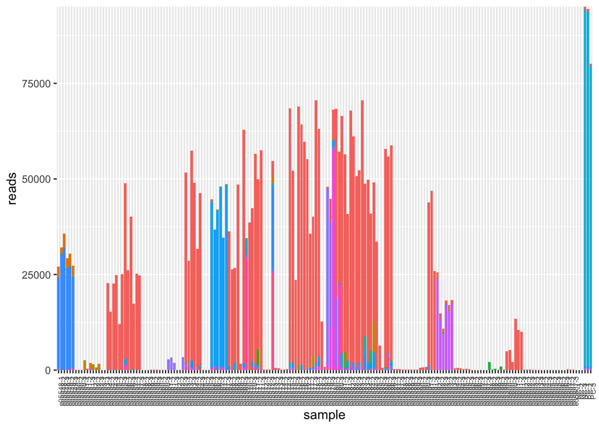

```r
tmp <- as.data.frame(st.brief)
sample_df <- rownames_to_column(tmp, var = "sample")

long_df <- sample_df %>%
  pivot_longer(2:length(sample_df)) %>%
  dplyr::rename(reads = value, ASV = name)

# long_df %>%
#   write_csv("csv_outputs/microkit_samples_20260324.csv")

long_df %>%
  filter(reads > 1) %>% # pretty minimal read filter
  ggplot(aes(x = sample, y = reads, fill = ASV)) +
  geom_bar(stat = "identity") +
  theme(
    legend.position = "none",
    axis.text.x = element_text(angle = 90, size = 6)
  ) +
  scale_y_continuous(expand = c(0,0))
```

```r
# ggsave("pdf_outputs/microkit_20260324_quicklook.png", width = 10, height = 4)
```

Use the custom blast database on Sedna to assign haplotypes for these data.

This was a little clunky for some reason…

```bash
blastn -db hapo_CR -query /home/dbaetscher/workdir/blast/HAPO_eDNA/hapo_20260413_ASV.csv -out CR_2025_results.txt -outfmt 6
```

```r
blast_results <- read_tsv("../data/blast_outputs/CR_2025_results.txt", col_names = F)
blast_data <- blast_results %>%
  dplyr::rename(ASV = X1, ref_id = X2, perc_id = X3, len = X4, mismatch = X5, gap = X6)

top_hits <- blast_data %>%
  group_by(ASV) %>%
  slice_max(order_by = perc_id, n = 1, with_ties = T)
```

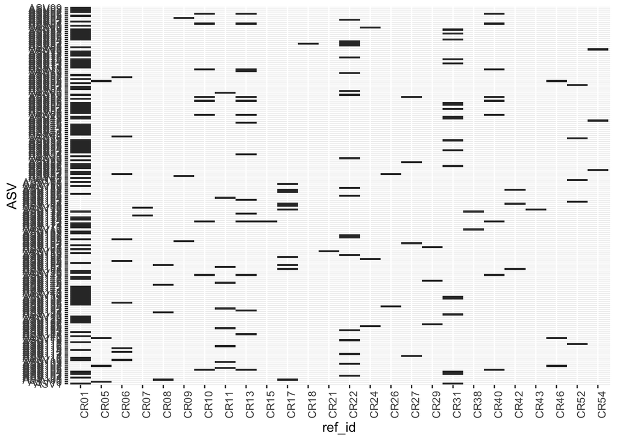

```r
top_hits %>%
  ggplot(aes(x = ref_id, y = ASV)) +
  geom_tile() +
  theme(
    axis.text.x = element_text(angle = 90)
  )
```

How many of the ASVs only match one CR?

```r
top_hits %>%
  add_tally(name = "n_CR_seqs") %>%
  filter(n_CR_seqs > 1)
```

```
## # A tibble: 98 × 13
## # Groups:   ASV [43]
##    ASV   ref_id perc_id   len mismatch   gap    X7    X8    X9   X10   X11   X12
##    <chr> <chr>    <dbl> <dbl>    <dbl> <dbl> <dbl> <dbl> <dbl> <dbl> <dbl> <dbl>
##  1 ASV1  CR01     100     379        0     0     1   379    18   396     0   701
##  2 ASV1  CR31     100     377        0     0     3   379    20   396     0   697
##  3 ASV1… CR17      97.1   379        9     1     1   377    18   396     0   638
##  4 ASV1… CR08      97.1   379        9     1     1   377    18   396     0   638
##  5 ASV1… CR01     100     376        0     0     1   376    18   393     0   695
##  6 ASV1… CR31     100     374        0     0     3   376    20   393     0   691
##  7 ASV1… CR01     100     379        0     0     1   379    18   396     0   701
##  8 ASV1… CR31     100     377        0     0     3   379    20   396     0   697
##  9 ASV1… CR40      99.5   379        2     0     1   379    18   396     0   689
## 10 ASV1… CR13      99.5   379        2     0     1   379    18   396     0   689
## # ℹ 88 more rows
## # ℹ 1 more variable: n_CR_seqs <int>
```

43 ASVs that supposedly match more than one CR haplotype and 148 ASVs that only match a single CR haplotype.

I could also be more stringent about mismatches.

Look at it the other way, how many ASVs match a given CR haplotype

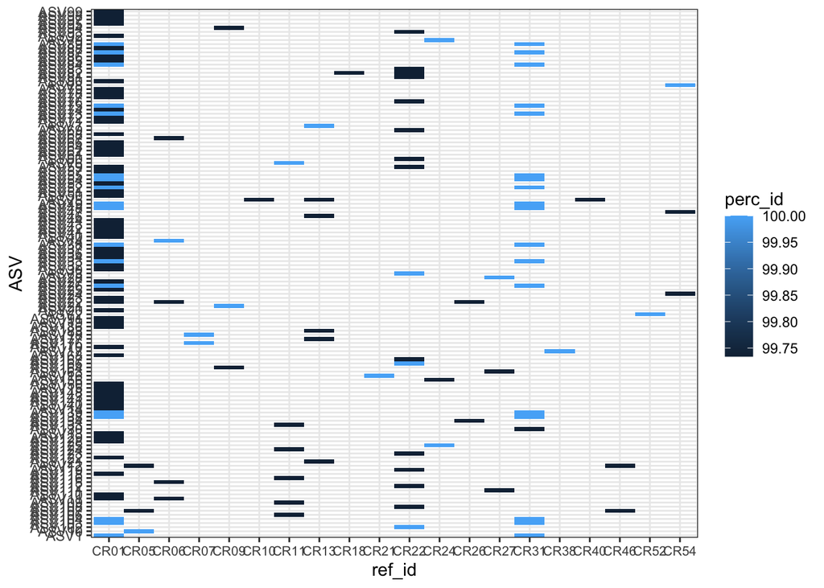

```r
long_df %>%
  left_join(., top_hits) %>%
  filter(reads > 1) %>%
  select(ASV, ref_id, perc_id, mismatch) %>%
  unique() %>%
  filter(mismatch < 2) %>%
  group_by(ref_id) %>%
  #tally(name = "n_ASV") %>%
  ggplot(aes(x = ref_id, y = ASV, fill = perc_id)) +
  geom_tile() +
  theme_bw() +
  theme(
    axis.text.x = element_text(size = 8)
  )
```

```r
ggsave("pdf_outputs/2025_samples_20260413.png", width = 8, height = 11)
```